# Future Perfect Models

Document Author: Jasmine Cui

```r
# Uncomment and run the following four lines to install necessary packages
# install.packages('tidyverse')
# install.packages('dplyr')
# install.packages('ggplot2')
# install.packages('xtable')
# install.packages('ggthemes')

# Load libraries
library(tidyverse)
library(xtable)
library(ggthemes)
```

# Data Exploration

```r
emotionFrequencies =
  emotionType %>%
  dplyr::group_by(., text_primary_emotion) %>%
  dplyr::summarize(., n = n()) %>%
  pivot_wider(., names_from = text_primary_emotion, values_from = n) %>%
  dplyr::mutate(., total = negative + neutral + positive) %>%
  dplyr::transmute(., negativePCT = negative/total, positivePCT = positive/total, neutralPCT = neutral/total)

emotionFrequencyTable =
  emotionFrequencies %>%
  xtable(.) %>%
  print(., type = 'html')
```

|  | negativePCT | positivePCT | neutralPCT |
| --- | --- | --- | --- |
| 1 | 0.38 | 0.59 | 0.03 |

Of course, as analysts we are interested in more than simply post emotion -- we also want to know how this relates to things like user engagement.

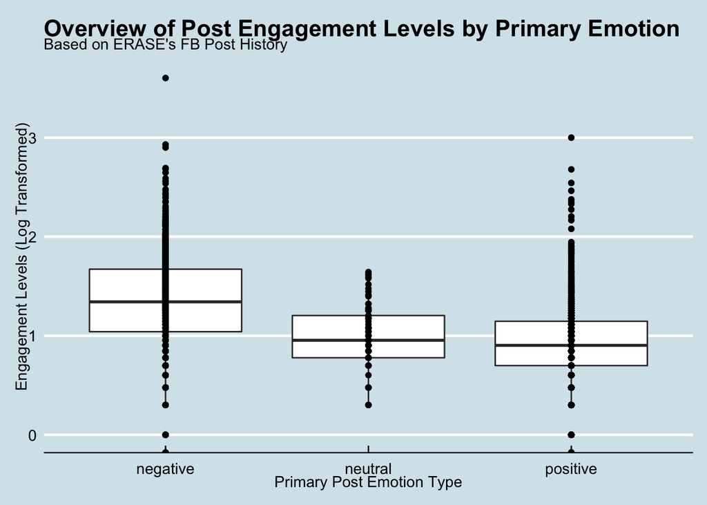

```r
emotionBox =
  emotionType %>%
  dplyr::mutate(., logEngagement = log10(emotionType$engagements)) %>%
  ggplot() +
  geom_boxplot(aes(x = sort(factor(text_primary_emotion)), y = logEngagement)) +
  geom_point(aes(x = sort(factor(text_primary_emotion)), y = logEngagement)) +
  xlab('Primary Post Emotion Type') +
  ylab('Engagement Levels (Log Transformed)') +
  ggtitle('Overview of Post Engagement Levels by Primary Emotion', subtitle = 'Based on ERASE\'s FB Post History') +
  theme_economist()

print(emotionBox)
```

Additionally, there are other dimensions to emotion beyond type. For instance, we may also want to look at emotional intensity and how both the type of emotion and its magnitude are related to user engagement.

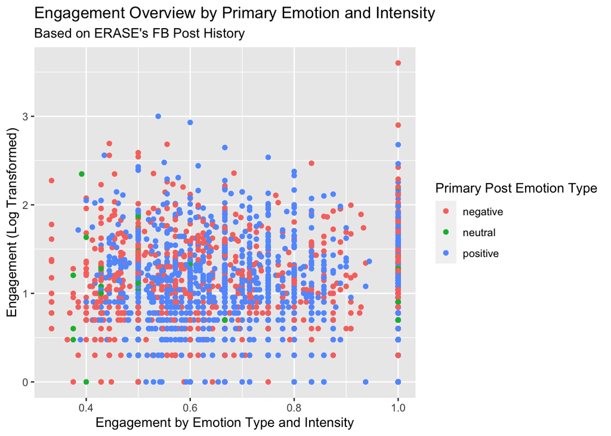

```r
emotionIntensity =
  emotionType %>%
  dplyr::mutate(., logEngagement = log10(engagements)) %>%
  dplyr::filter(., logEngagement >= 0) %>%
  ggplot(.) +
  geom_point(aes(x = text_emotional_intensity, y = logEngagement, color = text_primary_emotion)) +
  xlab('Engagement by Emotion Type and Intensity') +
  ylab('Engagement (Log Transformed)') +
  ggtitle('Engagement Overview by Primary Emotion and Intensity', subtitle = 'Based on ERASE\'s FB Post History') +
  labs(color = 'Primary Post Emotion Type')

print(emotionIntensity)
```

```r
postTime =
  emotionType %>%
  dplyr::mutate(., created_time = ifelse(is_created_night == 1, 'night', created_time)) %>%
  dplyr::mutate(., created_time = ifelse(is_created_evening == 1, 'evening', created_time)) %>%
  dplyr::mutate(., created_time = ifelse(is_created_morning == 1, 'morning', created_time)) %>%
  dplyr::mutate(., created_time = ifelse(is_created_afternoon == 1, 'afternoon', created_time)) %>%
  dplyr::mutate(., logEngagement = log10(emotionType$engagements)) %>%
  ggplot() +
  geom_boxplot(aes(y = logEngagement)) +
  facet_wrap(~ created_time) +
  xlab(NULL) +
  ylab('Engagement (Log Transformed)') +
  ggtitle('Post Engagement by at Different Times of Day', subtitle = 'Based on ERASE\'s FB Post History') +
  theme_economist()
```

Here, we can use OLS estimation to identify the effect of the time a post is made on a post's success in terms of engagement

```r
engagementTime =
  lm(engagements ~ is_created_night + is_created_afternoon + is_created_evening, data = emotionType) %>%
  summary(.)
```

Elaborating on this, we might also be interested in post timing with relation to other posts; if one post goes viral, it may be the case that the attention this post brings to ERASE's Facebook page also brings attention to immediately subsequent posts.

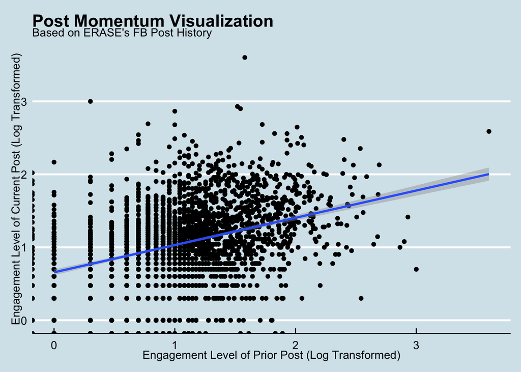

```r
engagementLag =
  futurePerfectFeature %>%
  dplyr::mutate(., log_engagements_last_post = log10(engagements_last_post), log_engagements = log10(engagements)) %>%
  ggplot(.) +
  geom_point(aes(x = log_engagements_last_post, y = log_engagements)) +
  xlab('Engagement Level of Prior Post (Log Transformed)') +
  ylab('Engagement Level of Current Post (Log Transformed)') +
  ggtitle('Post Momentum Visualization', subtitle = 'Based on ERASE\'s FB Post History') +
  geom_smooth(method = 'lm', aes(x = log_engagements_last_post, y = log_engagements)) +
  theme_economist()

print(engagementLag)
```

Clearly, there is a kind of relationship between the level of success a post achieves and that of the post after it and, furthermore, this relationship is approximately linear.

# The Particulars: A "Partialed Out" approach to modeling social media efficacy

```r
# I opted not to apply a log-linear transformation to engagement because ERASE's goal is to try and produce more "outlier" posts -- posts with extremely high engagement. However, if this priority changes, it may be useful to apply a log transformation to the engagements variable.

# Time
# Engagement conceptualized as a function of post-creation time
timeReg =
  lm(engagements ~ is_created_night + is_created_afternoon + is_created_evening, data = futurePerfectFeature) %>%
  summary(.)

timeReg
```

```
##
## Call:
## lm(formula = engagements ~ is_created_night + is_created_afternoon +
##     is_created_evening, data = futurePerfectFeature)
##
## Residuals:
##    Min     1Q Median     3Q    Max
##  -32.9  -19.8  -12.8   -2.1 3971.2
##
## Coefficients:
##                      Estimate Std. Error t value Pr(>|t|)
## (Intercept)            24.068      2.754   8.740   <2e-16 ***
## is_created_night        8.856      6.764   1.309   0.1906
## is_created_afternoon    2.763      3.869   0.714   0.4752
## is_created_evening     -8.406      4.821  -1.744   0.0813 .
## ---
## Signif. codes:  0 '***' 0.001 '**' 0.01 '*' 0.05 '.' 0.1 ' ' 1
##
## Residual standard error: 89.53 on 2860 degrees of freedom
## Multiple R-squared:  0.002646,   Adjusted R-squared:  0.0016
## F-statistic: 2.529 on 3 and 2860 DF,  p-value: 0.05556
```

```r
# Momentum/Timing
# Engagement conceptualized as a function of the engagement level of preceding post
momentumReg =
  lm(engagements ~ engagements_last_post, data = futurePerfectFeature) %>%
  summary(.)

momentumReg
```

```
##
## Call:
## lm(formula = engagements ~ engagements_last_post, data = futurePerfectFeature)
##
## Residuals:
##    Min     1Q Median     3Q    Max
## -124.4  -18.0  -13.3   -3.3 3972.3
##
## Coefficients:
##                       Estimate Std. Error t value Pr(>|t|)
## (Intercept)           21.65296    1.72542   12.55  < 2e-16 ***
## engagements_last_post  0.10780    0.01859    5.80 7.37e-09 ***
## ---
## Signif. codes:  0 '***' 0.001 '**' 0.01 '*' 0.05 '.' 0.1 ' ' 1
##
## Residual standard error: 89.11 on 2861 degrees of freedom
##   (1 observation deleted due to missingness)
## Multiple R-squared:  0.01162,    Adjusted R-squared:  0.01127
## F-statistic: 33.64 on 1 and 2861 DF,  p-value: 7.373e-09
```

```r
# Emotion + Emotional Intensity
# Engagement conceptualized as a function of both emotion and the intensity with which it is expressed
emotionReg =
  futurePerfectFeature %>%
  dplyr::mutate(., isPositive = ifelse(text_primary_emotion == 'Positive', 1, text_primary_emotion)) %>%
  dplyr::mutate(., isNegative = ifelse(text_primary_emotion == 'Negative', 1, text_primary_emotion)) %>%
  lm(engagements ~ text_emotional_intensity + isPositive + isNegative, .) %>%
  summary(.)

emotionReg
```

```
##
## Call:
## lm(formula = engagements ~ text_emotional_intensity + isPositive +
##     isNegative, data = .)
##
## Residuals:
##    Min     1Q Median     3Q    Max
##  -35.8  -18.5  -13.0   -2.5 3962.2
##
## Coefficients: (3 not defined because of singularities)
##                          Estimate Std. Error t value Pr(>|t|)
## (Intercept)               19.4791     3.9032   4.991 6.38e-07 ***
## text_emotional_intensity  15.4322    10.0441   1.536    0.125
## isPositivenegative         0.8877     8.3024   0.107    0.915
## isPositiveneutral        -11.4327    12.8908  -0.887    0.375
## isPositivepositive        -7.9942     8.3932  -0.952    0.341
## isNegativenegative             NA         NA      NA       NA
## isNegativeneutral              NA         NA      NA       NA
## isNegativepositive             NA         NA      NA       NA
## ---
## Signif. codes:  0 '***' 0.001 '**' 0.01 '*' 0.05 '.' 0.1 ' ' 1
##
## Residual standard error: 89.52 on 2859 degrees of freedom
## Multiple R-squared:  0.00329,    Adjusted R-squared:  0.001896
## F-statistic:  2.36 on 4 and 2859 DF,  p-value: 0.05129
```

```r
# Photo
# Engagement conceptualized as a function of whether or not a post has a photograph or not
photoReg =
  lm(engagements ~ is_photo, data = futurePerfectFeature) %>%
  summary(.)

photoReg
```

```
##
## Call:
## lm(formula = engagements ~ is_photo, data = futurePerfectFeature)
##
## Residuals:
##    Min     1Q Median     3Q    Max
##  -30.7  -18.6  -13.6   -3.6 3967.3
##
## Coefficients:
##             Estimate Std. Error t value Pr(>|t|)
## (Intercept)   22.586      1.881  12.008   <2e-16 ***
## is_photo       8.083      4.126   1.959   0.0502 .
## ---
## Signif. codes:  0 '***' 0.001 '**' 0.01 '*' 0.05 '.' 0.1 ' ' 1
##
## Residual standard error: 89.57 on 2861 degrees of freedom
##   (1 observation deleted due to missingness)
## Multiple R-squared:  0.00134,    Adjusted R-squared:  0.0009908
## F-statistic: 3.838 on 1 and 2861 DF,  p-value: 0.05019
```

```r
# Text Length
# Engagement conceptualized as a function of text length
textLengthReg =
  lm(engagements ~ text_length, data = futurePerfectFeature) %>%
  summary(.)

textLengthReg
```

```
##
## Call:
## lm(formula = engagements ~ text_length, data = futurePerfectFeature)
##
## Residuals:
##    Min     1Q Median     3Q    Max
##  -25.7  -19.0  -14.2   -3.5 3974.2
##
## Coefficients:
##             Estimate Std. Error t value Pr(>|t|)
## (Intercept) 23.75613    2.44617   9.712   <2e-16 ***
## text_length  0.01640    0.05785   0.283    0.777
## ---
## Signif. codes:  0 '***' 0.001 '**' 0.01 '*' 0.05 '.' 0.1 ' ' 1
##
## Residual standard error: 89.62 on 2862 degrees of freedom
## Multiple R-squared:  2.807e-05,  Adjusted R-squared:  -0.0003213
## F-statistic: 0.08033 on 1 and 2862 DF,  p-value: 0.7769
```